# Reconstrucción filogenética

## Objetivos

Obtener una filogenia calibrada de homininos y algunos primates, a partir de secuencias mitocondriales.

## Ejercicio 1

# Leer los datos en R

```r
library(phangorn)
mtdna <- read.phyDat('mtDNA.fasta', format = 'fasta')
glance(mtdna)
```

```
  nseq nchar unique_site_pattern parsimony_informative_sites const_sites
1   42 16603                 974                        2047       13482
```

**Nota** Sería sensato reducir el conjunto de datos. ¿Qué secuencias eliminarías? Si quieres, puedes intentarlo con la función subset().

# Escoger el modelo de evolución

Evaluar los 92 modelos posibles puede llevar un rato…

```r
modelos <- modelTest(mtdna, control = pml.control(trace = 0))
```

Si tienes más de un procesador (y si tienes el paquete parallel instalado), puedes pedirle que los use:

```r
modelos <- modelTest(mtdna, control = pml.control(trace = 0),
                     multicore = TRUE, mc.cores = 2)
```

Si no has tenido paciencia para dejar que termine la búsqueda, puedes usar el modelo más complejo: GTR+G(4)+I, porque la cantidad de datos lo permite, aunque en realidad el modelo con menor BIC es otro.

El mejor modelo, o al menos el que da un BIC menor, es el TIM2+G(4)+I (4 categorías discretas de factor alfa en la distribucción gamma, la I añade una categoría de la proporción de sitios invariables). También podemos usar de criterio el AIC o especificar un modelo diferente.

```r
fit <- as.pml(modelos,'TIM2+G(4)+I')
show(fit)
```

```
model: TIM2+G(4)+I
loglikelihood: -44351.3
unconstrained loglikelihood: -45918.42
Proportion of invariant sites: 0.6119768
Model of rate heterogeneity: Discrete gamma model
Number of rate categories: 4
Shape parameter: 0.9224089
       Rate Proportion
1 0.0000000  0.6119768
2 0.3124145  0.0970058
3 1.1651875  0.0970058
4 2.5407023  0.0970058
5 6.2903579  0.0970058

Rate matrix:
          a         c        g         t
a  0.000000  2.135686 66.51601  2.135686
c  2.135686  0.000000  1.00000 54.134840
g 66.516009  1.000000  0.00000  1.000000
t  2.135686 54.134840  1.00000  0.000000

Base frequencies:
        a         c         g         t
0.3093660 0.3113173 0.1307058 0.2486109
```

# NJ y UPGMA

La función dist.ml() de phangorn solo permite usar distancias de Juke Cantor y de Felsenstein 1981 con ADN. Para usar otros modelos, debemos usar la función dist.dna() del paquete ape (automáticamente cargado con phangorn), que se aplica a objetos de clase DNAbin. Por eso, usamos la función as.DNAbin() para presentarle a dist.dna() los datos en el formato adecuado. En cualquier caso, dist.dna() tampoco implementa todos los modelos.

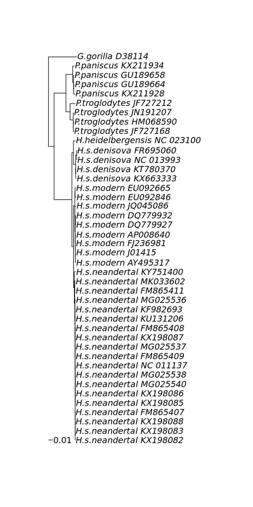

```r
mt_nj    <-    NJ(dist.dna(as.DNAbin(mtdna), model = 'TN93', gamma = 0.93))
mt_upgma <- upgma(dist.dna(as.DNAbin(mtdna), model = 'TN93', gamma = 0.93))
plot(midpoint(mt_nj))
add.scale.bar()
```

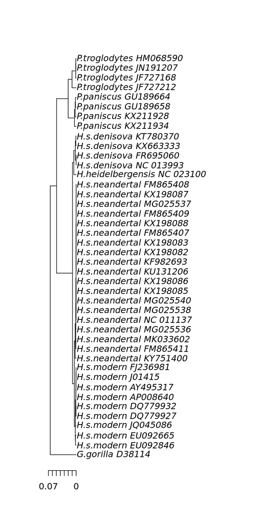

```r
plot(mt_upgma)
axisPhylo()
```

No podemos utilizar este modelo (TIM2+G(4)+I) porque no está implementado en esta función. Pasamos a emplear el que estaba por defecto, TN93 (parece que el que nos salía como mejor es importante para obtener el árbol de máxima verosimilitud, con este para calcular distancias con este nos vale).

**Nota** Cuando la función plot() se aplica a un objeto de clase phylo, en realidad se ejecuta la función plot.phylo(). Si quieres explorar las opciones de representación gráfica de árboles con plot(), consulta help(plot.phylo).

¿Por qué usamos midpoint() al representar gráficamente el árbol de NJ?

Los árboles generados por el modelo NJ no son enraizados. Con esta función, lo que conseguimos es un árbol enraizado, al poner la raíz en el punto medio.

# Podemos enraizar el árbol

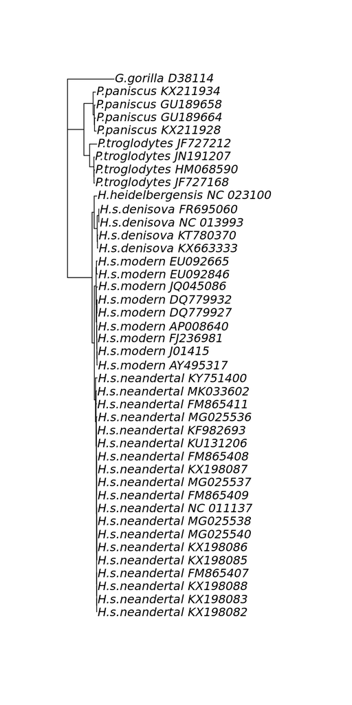

```r
enraizado <- root(mt_nj, 'G.gorilla_D38114')
plot(enraizado)
```

# Máxima verosimilitud

```r
veros <- pml_bb(fit,
                ratchet.par = ratchet.control(maxit = 5L),
                control = pml.control(trace = 1, maxit = 5))
```

```
optimize edge weights:  -44351.28 --> -44351.28
optimize rate matrix:  -44351.28 --> -44351.28
optimize invariant sites:  -44351.28 --> -44351.27
optimize shape parameter:  -44351.27 --> -44351.27
optimize edge weights:  -44351.27 --> -44351.27
optimize topology:  -44351.27 --> -44351.27  NNI moves:  3
optimize rate matrix:  -44351.27 --> -44351.27
optimize invariant sites:  -44351.27 --> -44351.27
optimize shape parameter:  -44351.27 --> -44351.27
optimize edge weights:  -44351.27 --> -44351.27
optimize topology:  -44351.27 --> -44351.27  NNI moves:  0
optimize topology:  -46299.38 --> -44444.99  NNI moves:  19
Ratchet iteration  1 , best pscore so far: -44351.27
optimize topology:  -45765.5 --> -44351.27  NNI moves:  16
Ratchet iteration  2 , best pscore so far: -44351.27
optimize topology:  -44786.91 --> -44351.27  NNI moves:  16
Ratchet iteration  3 , best pscore so far: -44351.27
optimize topology:  -45179.09 --> -44351.27  NNI moves:  15
Ratchet iteration  4 , best pscore so far: -44351.27
optimize topology:  -45455.5 --> -44351.27  NNI moves:  16
Ratchet iteration  5 , best pscore so far: -44351.27
optimize rate matrix:  -44351.27 --> -44351.27
optimize invariant sites:  -44351.27 --> -44351.27
optimize shape parameter:  -44351.27 --> -44351.27
optimize edge weights:  -44351.27 --> -44351.27
optimize topology:  -44351.27 --> -44351.27  NNI moves:  0
optimize rate matrix:  -44351.27 --> -44351.27
optimize invariant sites:  -44351.27 --> -44351.27
optimize shape parameter:  -44351.27 --> -44351.27
optimize edge weights:  -44351.27 --> -44351.27
optimize rate matrix:  -44351.27 --> -44351.27
optimize invariant sites:  -44351.27 --> -44351.26
optimize shape parameter:  -44351.26 --> -44351.26
optimize edge weights:  -44351.26 --> -44351.26
optimize rate matrix:  -44351.26 --> -44351.26
optimize invariant sites:  -44351.26 --> -44351.26
optimize shape parameter:  -44351.26 --> -44351.26
optimize edge weights:  -44351.26 --> -44351.26
optimize rate matrix:  -44351.26 --> -44351.26
optimize invariant sites:  -44351.26 --> -44351.26
optimize shape parameter:  -44351.26 --> -44351.26
optimize edge weights:  -44351.26 --> -44351.26
optimize rate matrix:  -44351.26 --> -44351.26
optimize invariant sites:  -44351.26 --> -44351.26
optimize shape parameter:  -44351.26 --> -44351.26
optimize edge weights:  -44351.26 --> -44351.26
```

En este caso, sí que podemos utilizar este modelo que nos salía como óptimo, estamos trabajando con esta función que sí que nos lo permite (además habíamos dicho que era interesante para obtener el árbol de máxima verosimilitud, este caso). -Lo hemos intentado, pero no dejaba. Lo que nos pasaba es que estaba haciendo demasiadas iteraciones, hemos intentado limitar este número con “maxit” (máximo número de iteraciones)-

El objeto veros, de clase pml, contiene el árbol (veros$tree), además de los parámetros optimizados del modelo. Podemos enraizar el árbol usando al gorila como outgroup:

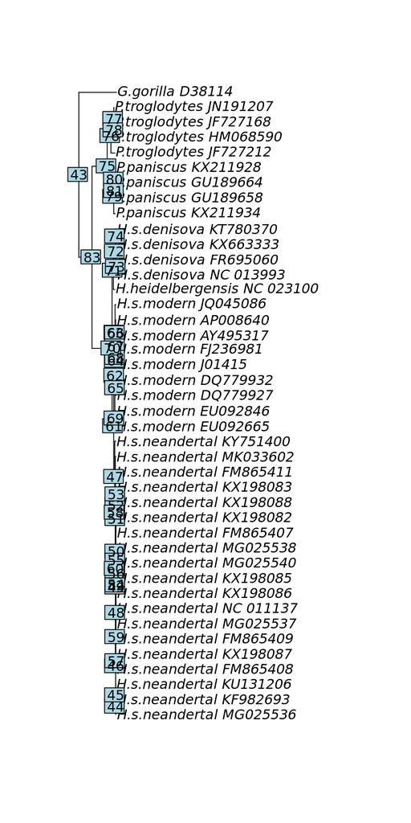

```r
mt_ml <- root(veros$tree, 'G.gorilla_D38114')
plot(midpoint(mt_ml))
nodelabels()
```

También podemos extraer un subárbol para visualizarlo mejor. Con nodelabels() identifico fácilmente cual es el nodo en el que quiero recortar el árbol:

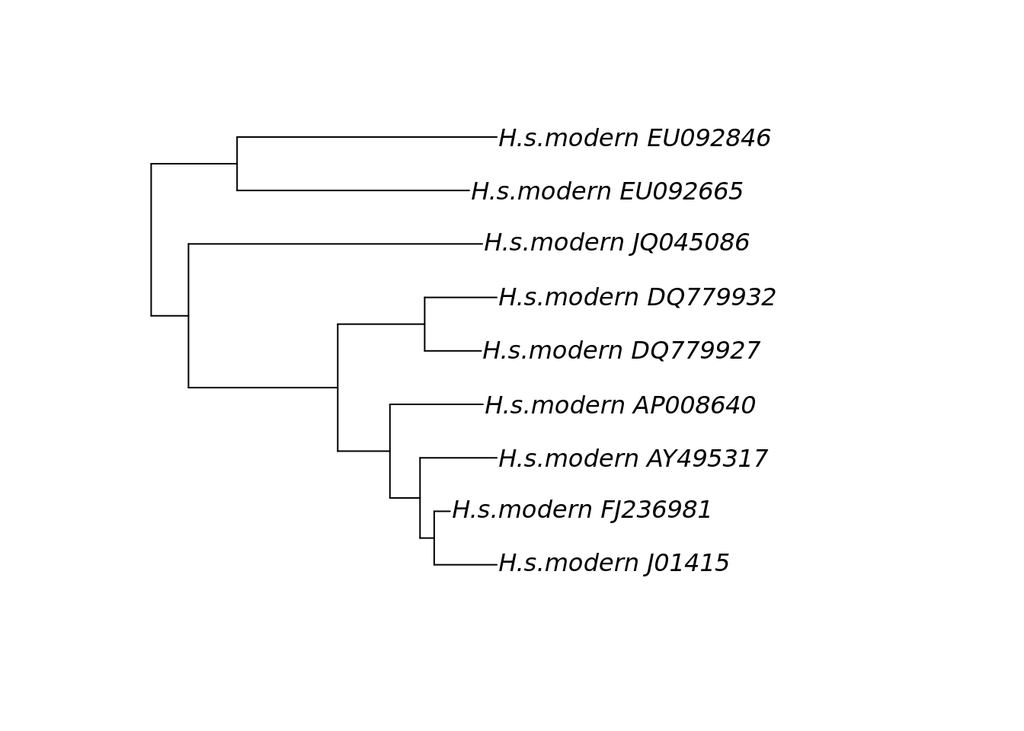

```r
homo <- extract.clade(mt_ml, 62)
plot(midpoint(homo))
```

## Con datación de puntas (tip dating)

Sabiendo que algunas secuencias dejaron de evolucionar hace tiempo (mira el apéndice), podemos intentar calibrar las tasas de sustitución con esta información. Para ello necesitamos un vector de fechas con nombres, donde cada fecha lleva el nombre de la secuencia a la que corresponde. Podemos dar el valor 0 a todas las secuencias contemporáneas y valores negativos, en años, a las secuencias arcaicas.

```r
fechas <- c(0, 0, 0, 0, 0, 0, 0, 0, 0,
              -400000,
              -39000, -50000, -110000, -110000,
              -39820, -40096, -38515, -38310, -39000, -40000, -41210,
              -42430, -42540, -43230, -43780, -44290, -44770, -49000,
              -50000, -82752, -65000, -122287, -110450,
              0, 0, 0, 0, 0, 0, 0, 0, 0)
setNames(fechas, names(mtdna))
```

```
           G.gorilla_D38114      P.troglodytes_JF727212
                          0                           0
     P.troglodytes_JN191207      P.troglodytes_JF727168
                          0                           0
     P.troglodytes_HM068590         P.paniscus_KX211934
                          0                           0
        P.paniscus_KX211928         P.paniscus_GU189658
                          0                           0
        P.paniscus_GU189664 H.heidelbergensis_NC_023100
                          0                     -400000
     H.s.denisova_NC_013993       H.s.denisova_FR695060
                     -39000                      -50000
      H.s.denisova_KX663333       H.s.denisova_KT780370
                    -110000                     -110000
    H.s.neandertal_KX198085     H.s.neandertal_KX198086
                     -39820                      -40096
    H.s.neandertal_MG025538    H.s.neandertal_NC_011137
                     -38515                      -38310
    H.s.neandertal_FM865409     H.s.neandertal_FM865407
                     -39000                      -40000
    H.s.neandertal_KX198088     H.s.neandertal_KX198083
                     -41210                      -42430
    H.s.neandertal_MG025540     H.s.neandertal_MG025536
                     -42540                      -43230
    H.s.neandertal_MG025537     H.s.neandertal_KX198087
                     -43780                      -44290
    H.s.neandertal_KX198082     H.s.neandertal_FM865408
                     -44770                      -49000
    H.s.neandertal_KU131206     H.s.neandertal_KF982693
                     -50000                      -82752
    H.s.neandertal_FM865411     H.s.neandertal_KY751400
                     -65000                     -122287
    H.s.neandertal_MK033602         H.s.modern_EU092846
                    -110450                           0
        H.s.modern_EU092665         H.s.modern_JQ045086
                          0                           0
        H.s.modern_DQ779927         H.s.modern_DQ779932
                          0                           0
        H.s.modern_AP008640         H.s.modern_AY495317
                          0                           0
          H.s.modern_J01415         H.s.modern_FJ236981
                          0                           0
```

```r
fit_td <- pml_bb(mtdna, model = 'TIM2+G(4)+I', method = 'tipdated',
                 tree = enraizado,
                 tip.dates = fechas, rearrangement = 'NNI',
                 ratchet.par = ratchet.control(maxit = 5L),
                 control = pml.control(trace = 1, maxit = 5))
```

```
optimize edge weights:  -52752.42 --> -49831.19
optimize rate:  -49831.19 --> -49831.19
optimize rate matrix:  -49831.19 --> -46604.23
optimize invariant sites:  -46604.23 --> -46359.55
optimize shape parameter:  -46359.55 --> -46359.54
optimize edge weights:  -46359.54 --> -46340.52
optimize topology:  -46340.52 --> -46551.45  NNI moves:  11
optimize rate:  -46551.45 --> -46551.45
optimize rate matrix:  -46551.45 --> -46550.35
optimize invariant sites:  -46550.35 --> -46462.26
optimize shape parameter:  -46462.26 --> -46462.17
optimize edge weights:  -46462.17 --> -46456.7
optimize topology:  -46456.7 --> -46456.04  NNI moves:  0
optimize rate:  -46456.04 --> -46456.04
optimize rate matrix:  -46456.04 --> -46455.41
optimize invariant sites:  -46455.41 --> -46454.7
optimize shape parameter:  -46454.7 --> -46454.61
optimize edge weights:  -46454.61 --> -46453.69
optimize rate:  -46453.69 --> -46453.69
optimize rate matrix:  -46453.69 --> -46453.68
optimize invariant sites:  -46453.68 --> -46453.57
optimize shape parameter:  -46453.57 --> -46453.47
optimize edge weights:  -46453.47 --> -46452.7
optimize rate:  -46452.7 --> -46452.7
optimize rate matrix:  -46452.7 --> -46452.7
optimize invariant sites:  -46452.7 --> -46452.6
optimize shape parameter:  -46452.6 --> -46452.49
optimize edge weights:  -46452.49 --> -46451.77
optimize rate:  -46451.77 --> -46451.77
optimize rate matrix:  -46451.77 --> -46451.77
optimize invariant sites:  -46451.77 --> -46451.67
optimize shape parameter:  -46451.67 --> -46451.55
optimize edge weights:  -46451.55 --> -46450.84
optimize rate:  -46450.84 --> -46450.84
optimize rate matrix:  -46450.84 --> -46450.84
optimize invariant sites:  -46450.84 --> -46450.72
optimize shape parameter:  -46450.72 --> -46450.6
optimize edge weights:  -46450.6 --> -46449.89
```

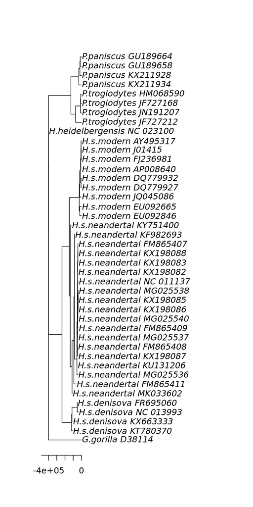

```r
plot(fit_td)
```

# Determinación de distancias

```r
estimate.mu(mt_ml, node.dates = fechas)
```

```
[1] 2.198517e-08
```